[figure not shown]

# ESTADISTICA PARA EL SECTOR PUBLICO

- Profesor: [Dr. José Manuel Magallanes, Ph.D.](http://www.pucp.edu.pe/profesor/jose-manuel-magallanes/)
  - Profesor del Departamento de Ciencias Sociales, Sección de Ciencia Política y Gobierno.
  - [Oficina 105](https://goo.gl/maps/xuGeG6o9di1i1y5m6) - Edificio CISEPA / ECONOMIA / CCSS
  - Telefono: (51) 1 - 6262000 anexo 4302
  - Correo Electrónico: jmagallanes@pucp.edu.pe

# Sesión 3: Exploración Bivariada

Si la exploración univariada nos sugirió problemas, la bivariada nos sugerirá respuestas. Este es un momento crítico pues nos debemos confundirnos. Son solo sugerencias, y estadisticamente no sabemos si es causalidad; solo nos acercamos a ver asociación, y en ese caso de tipo lineal; es decir, saber si el el aumento de los valores de una variable coinciden con el aumento o disminución de los valores de otra.

Exploremos el gasto a nivel de gobierno de gobierno nacioal segun los datos ofrecidos por el mef en su pagina de [consulta amigable](https://www.mef.gob.pe/es/seguimiento-de-la-ejecucion-presupuestal-consulta-amigable). Los datos los ves a continuación en GoogleSheets:

[interactive chart not shown]

Nuestro análisis bivariado lo haremos sobre dos situaciones:

- Cuando tenemos dos columnas numericas.
- Cuando tenemos una columna numerica y una columna categorica.

## Caso 1: Una columna numérica y una categórica:

Aqui usaremos el modelo 2:

```r
# link a google:
lk2="https://docs.google.com/spreadsheets/d/e/2PACX-1vSIzeNWn9X1UIhEWY3pnAPdUdSP9Ni7k2btVnt9GuatiSexZCAVmn09INK2fpeY8SqKPWciBI4OSfRh/pub?gid=1108202370&single=true&output=csv"

# colectando datos
gasto2=read.csv(lk2,stringsAsFactors = F)
```

Veamos cómo se trajo la data:

```r
str(gasto2)
```

```
## 'data.frame':    60 obs. of  9 variables:
##  $ sector            : chr  "01: PRESIDENCIA CONSEJO MINISTROS" "03: CULTURA" "04: PODER JUDICIAL" "05: AMBIENTAL" ...
##  $ pia               : num  1.63e+09 4.48e+08 1.82e+09 5.23e+08 1.87e+09 ...
##  $ pim               : num  2.02e+09 5.43e+08 2.12e+09 6.49e+08 1.74e+09 ...
##  $ certificacion     : num  1.72e+09 4.89e+08 2.11e+09 5.36e+08 1.50e+09 ...
##  $ compromiso_anual  : num  1.71e+09 4.88e+08 2.09e+09 5.25e+08 1.49e+09 ...
##  $ atencioncompromiso: num  1.71e+09 4.88e+08 2.09e+09 5.25e+08 1.49e+09 ...
##  $ devengado         : num  1.70e+09 4.88e+08 2.09e+09 5.25e+08 1.49e+09 ...
##  $ girado            : num  1.70e+09 4.87e+08 2.08e+09 5.24e+08 1.49e+09 ...
##  $ periodo           : int  2016 2016 2016 2016 2016 2016 2016 2016 2016 2016 ...
```

Periodo lo usaremos como variable categórica:

```r
gasto2$periodo=as.factor(gasto2$periodo)
```

Queremos testear la **hipotesis** que el nivel de avance entre un año de primer mandato y dos años después es diferente, y quizas hallar que se avanza más luego de pasado el primer año de mandato (efectivo desde medio año). El avance lo define el MEF como la tasa entre devengado y presupuesto inicial modificado. Calculemos esa **nueva** variable:

```r
gasto2$avance=gasto2$devengado/gasto2$pim
```

Aquí podemos ver ambas medias:

```r
# numerico, factor, funcion
tapply(gasto2$avance,gasto2$periodo, FUN = mean)
```

```
##      2016      2018
## 0.9010214 0.9002689
```

O mas detalles:

```r
# numerico, factor, funcion
tapply(gasto2$avance,gasto2$periodo, FUN = summary)
```

```
## $`2016`
##    Min. 1st Qu.  Median    Mean 3rd Qu.    Max.
##  0.7957  0.8401  0.9201  0.9010  0.9615  0.9839
##
## $`2018`
##    Min. 1st Qu.  Median    Mean 3rd Qu.    Max.
##  0.7326  0.8577  0.9201  0.9003  0.9546  0.9976
```

Visualizar con histograma:

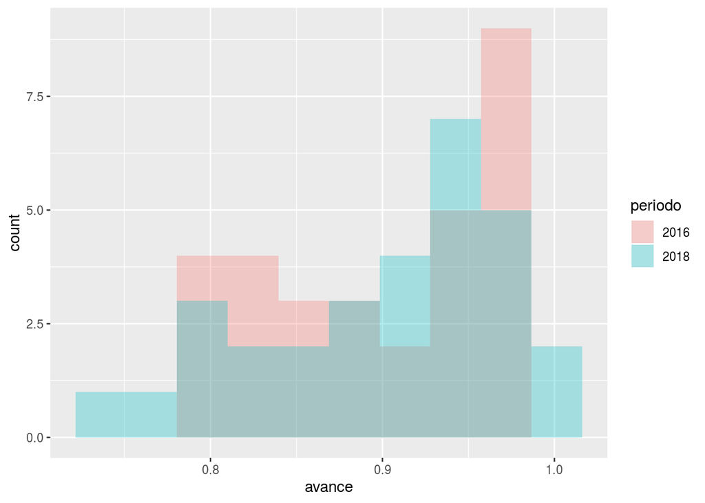

```r
library(ggplot2)
ggplot(gasto2, aes(x=avance, fill=periodo)) +
    geom_histogram(bins=10, alpha=.3, position="identity")
```

O con boxplot:

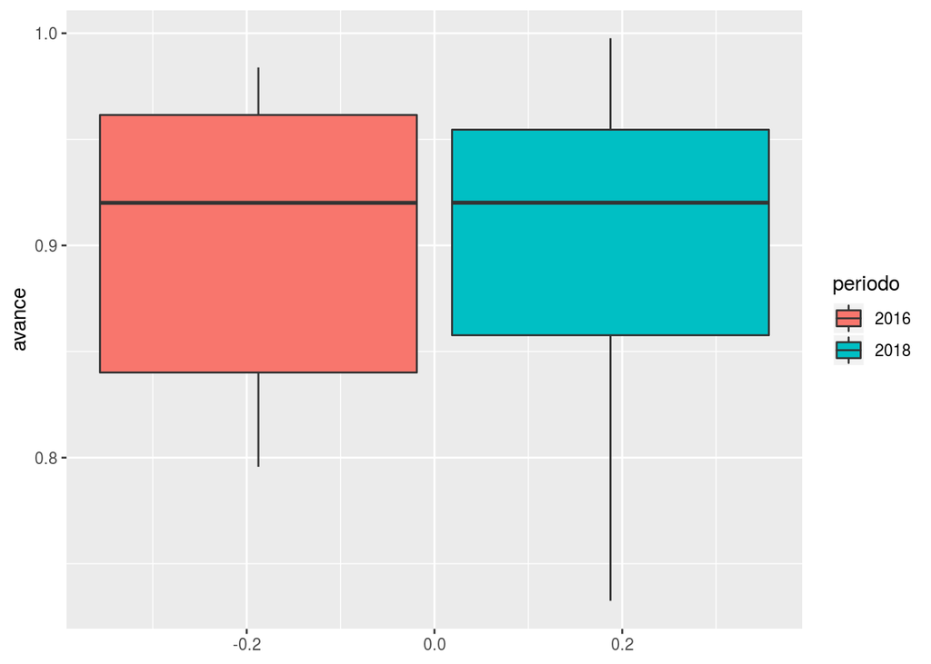

```r
ggplot(gasto2, aes(y=avance, fill=periodo)) + geom_boxplot()
```

Habrá variación en promedio?

```r
summary(aov(avance~periodo, data=gasto2))
```

```
##             Df  Sum Sq  Mean Sq F value Pr(>F)
## periodo      1 0.00001 0.000008   0.002  0.966
## Residuals   58 0.26750 0.004612
```

La probabilidad que las medias sean iguales es muy alta (0.966); para rechazar la igualdad por convención se usa una probabilidad menor a 0.05.

Lo mismo obtendríamos con su simil no-paramétrico:

```r
kruskal.test(avance~periodo, data=gasto2)
```

```
##
##  Kruskal-Wallis rank sum test
##
## data:  avance by periodo
## Kruskal-Wallis chi-squared = 0.0034973, df = 1, p-value = 0.9528
```

## Caso 2: Dos columnas numéricas

Aquí podemos usar el modelo 1:

```r
# link a google:
lk1="https://docs.google.com/spreadsheets/d/e/2PACX-1vSIzeNWn9X1UIhEWY3pnAPdUdSP9Ni7k2btVnt9GuatiSexZCAVmn09INK2fpeY8SqKPWciBI4OSfRh/pub?gid=0&single=true&output=csv"

# colectando datos
gasto1=read.csv(lk1,stringsAsFactors = F)
```

Veamos cómo se trajo la data:

```r
str(gasto1)
```

```
## 'data.frame':    30 obs. of  16 variables:
##  $ sector                 : chr  "01: PRESIDENCIA CONSEJO MINISTROS" "03: CULTURA" "04: PODER JUDICIAL" "05: AMBIENTAL" ...
##  $ sectorn                : chr  "PCM" "CUL" "PJ" "AMB" ...
##  $ pia2016G               : num  1.63e+09 4.48e+08 1.82e+09 5.23e+08 1.87e+09 ...
##  $ pim2016G               : num  2.02e+09 5.43e+08 2.12e+09 6.49e+08 1.74e+09 ...
##  $ certificacion2016G     : num  1.72e+09 4.89e+08 2.11e+09 5.36e+08 1.50e+09 ...
##  $ compromiso_anual2016G  : num  1.71e+09 4.88e+08 2.09e+09 5.25e+08 1.49e+09 ...
##  $ atencioncompromiso2016G: num  1.71e+09 4.88e+08 2.09e+09 5.25e+08 1.49e+09 ...
##  $ devengado2016G         : num  1.70e+09 4.88e+08 2.09e+09 5.25e+08 1.49e+09 ...
##  $ girado2016G            : num  1.70e+09 4.87e+08 2.08e+09 5.24e+08 1.49e+09 ...
##  $ pia2018G               : num  8.77e+09 5.93e+08 2.29e+09 6.06e+08 1.93e+09 ...
##  $ pim2018G               : num  7.24e+09 6.19e+08 2.49e+09 6.82e+08 2.17e+09 ...
##  $ certificacion2018G     : num  5.36e+09 5.92e+08 2.47e+09 6.37e+08 1.98e+09 ...
##  $ compromiso_anual2018G  : num  5.31e+09 5.88e+08 2.47e+09 6.31e+08 1.97e+09 ...
##  $ atencioncompromiso2018G: num  5.31e+09 5.84e+08 2.47e+09 6.26e+08 1.81e+09 ...
##  $ devengado2018G         : num  5.30e+09 5.84e+08 2.38e+09 6.24e+08 1.73e+09 ...
##  $ girado2018G            : num  5.30e+09 5.83e+08 2.38e+09 6.24e+08 1.73e+09 ...
```

Sabiendo lo anterior, nuestra curiosidad aumenta en saber si cada uno de los sectores aumento de un año a dos años despues. Calculemos las **nuevas** variables *avance* para ambos años:

```r
# para 2016
gasto1$avance2016=gasto1$devengado2016G/gasto1$pim2016G

# para 2018
gasto1$avance2018=gasto1$devengado2018G/gasto1$pim2018G
```

Exploremos el coeficiente de correlación:

```r
cor.test(~avance2016 + avance2018, data = gasto1)
```

```
##
##  Pearson's product-moment correlation
##
## data:  avance2016 and avance2018
## t = 4.0211, df = 28, p-value = 0.000397
## alternative hypothesis: true correlation is not equal to 0
## 95 percent confidence interval:
##  0.3130048 0.7925543
## sample estimates:
##       cor
## 0.6050455
```

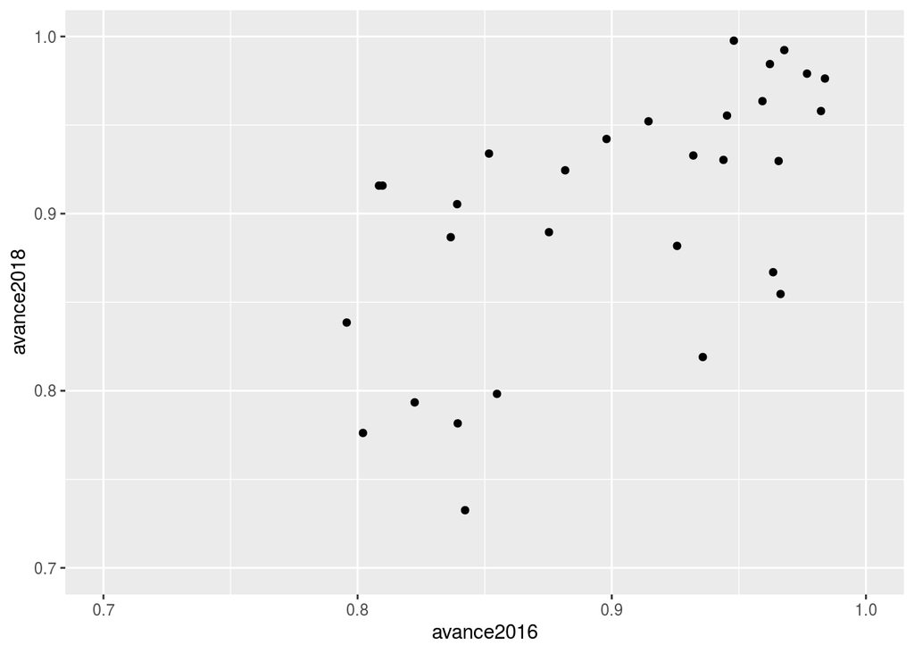

```r
base = ggplot(gasto1, aes(avance2016, avance2018, label = sectorn))
scatterplot1 = base + geom_point()  +
              xlim(0.7,1) + ylim(0.7,1)
scatterplot1
```

Pero podemos ir un paso más allá y sugerir un modelo de regresión. Produzcamos otra gráfica:

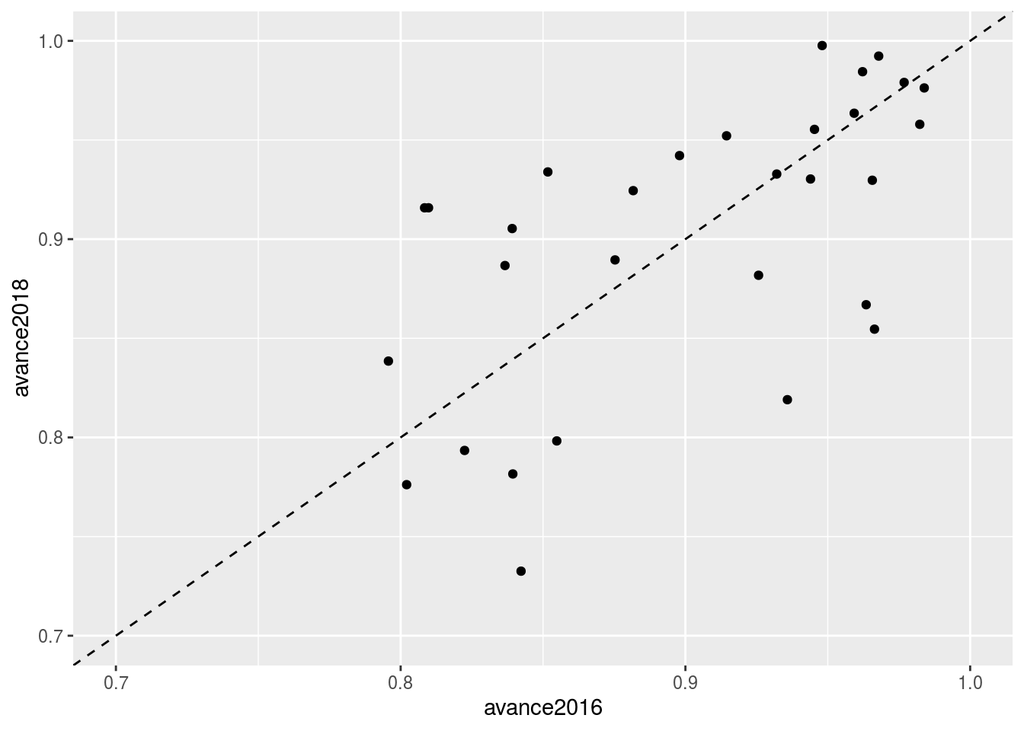

```r
base = ggplot(gasto1, aes(avance2016, avance2018, label = sectorn))
scatterplot1 = base + geom_point()  +
              xlim(0.7,1) + ylim(0.7,1)
scatterplot2 = scatterplot1 + geom_abline(linetype = "dashed")
scatterplot2
```

Veamos cada sector:

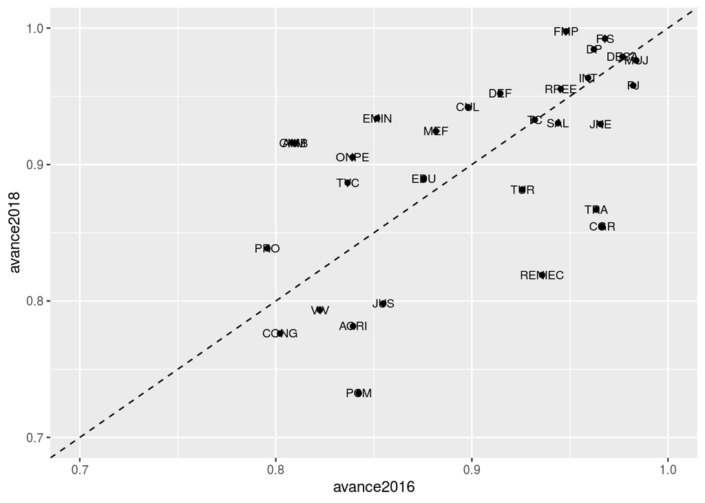

```r
scatterplot2 + geom_text(size = 3)
```

Mejoremos las etiquetas:

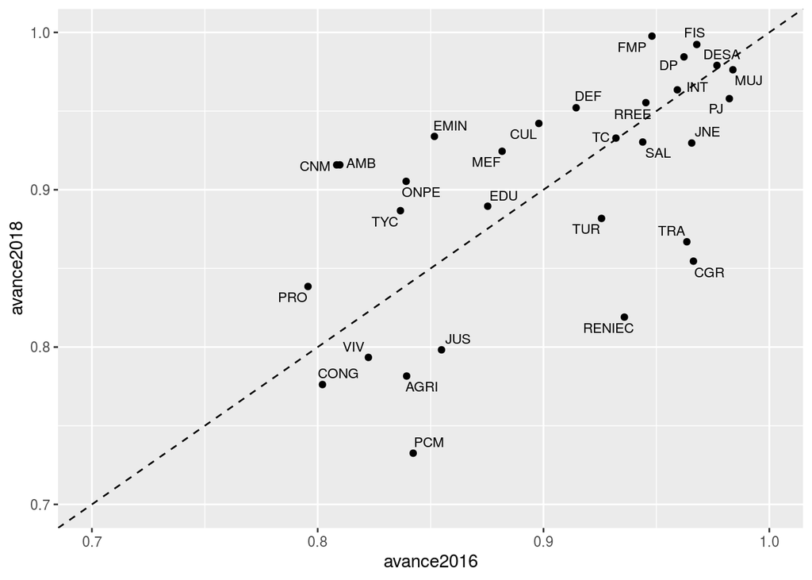

```r
library(ggrepel)

scatterplot2 +geom_text_repel(size=3)
```

Se nota que hay sectores que mejoran, pero otros no. Veamos la regresión:

```r
regre=lm(avance2018~avance2016,data = gasto1)
summary(regre)
```

```
##
## Call:
## lm(formula = avance2018 ~ avance2016, data = gasto1)
##
## Residuals:
##      Min       1Q   Median       3Q      Max
## -0.12738 -0.04853  0.01518  0.04251  0.07912
##
## Coefficients:
##             Estimate Std. Error t value Pr(>|t|)
## (Intercept)   0.2817     0.1542   1.827 0.078427 .
## avance2016    0.6865     0.1707   4.021 0.000397 ***
## ---
## Signif. codes:  0 '***' 0.001 '**' 0.01 '*' 0.05 '.' 0.1 ' ' 1
##
## Residual standard error: 0.05838 on 28 degrees of freedom
## Multiple R-squared:  0.3661, Adjusted R-squared:  0.3434
## F-statistic: 16.17 on 1 and 28 DF,  p-value: 0.000397
```

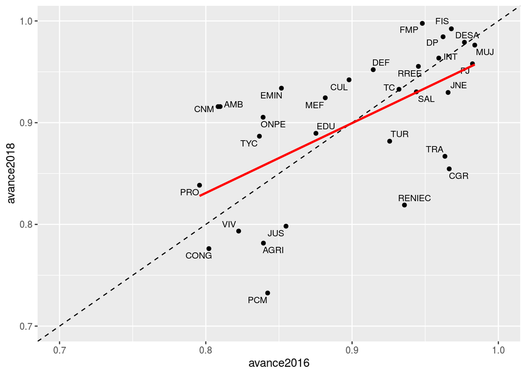

```r
scatterplot2 +geom_text_repel(size=3) + geom_smooth(method = "lm", se = FALSE, color='red')
```

Esto NO indica que haya descenso, pero sí indica que el ángulo de la diagonal es mayor al de la la recta de regresión. ¿Que necesesitaríamos para una “mejor” recta de regresión?

Volver al [INDICE DEL CURSO](https://politicaygobiernopucp.github.io/EstadisticaSectorPublico/)